# act_report_PICTURESwrong-Copy1

## We Rate Dogs: Twitter users rate their dogs at an average of 10.63 out of 10

#### ... because they're good dogs

[figure not shown]

Twitter users rated dogs: from 2015 to 2017 more than 5000 tweets were sent and saved in the "We rate dogs" Twitter archive. 338 Twitter users also classified the dogs in one of the so called "dog stages":

- pupper
- puppo
- doggo
- floofer

Additionally, an AI made predictions of the dog breed based on pictures of the dogs. 537 dogs were not classified in any particular dog breed.

After analyzing 2141 original tweets, each representing a single dog, I gained the following **insights:

### The number of favorite votings and retweets correlated moderately positively to the dog rating

The table below is a Spearman correlation matrix of the dog rating (between 0 and 14), correlated to the number of retweets and the number of favorite votes. Spearman's correlation coefficient, which uses ranked scores was chosen due to non-normality.

The separate correlations between dog rating and: 1) number of retweets; 2) number of favorite votes are illustrated with combined plots below the correlation matrix. The non-normality is obvious by the histograms on the side axes:

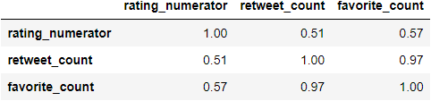

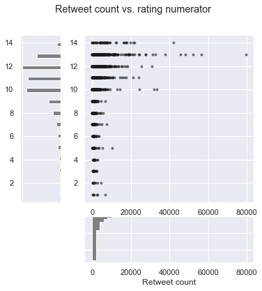

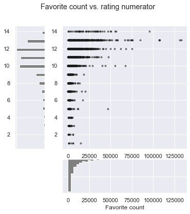

### Puppos and doggos were rated the highest, followed by floofers,

### mentioning a dog stage was related to a higher rating

For puppers, meantioning their stage was not related to a higher rating (compared to tweets without mention of dog stage).

Regression coefficients with p-values are depicted below:

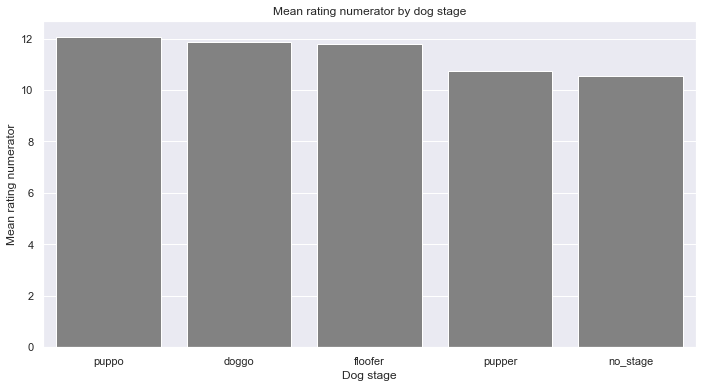

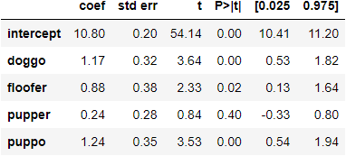

### The predicted dog breed did not influence the rating

The most abundant dog breed among the predicted dog breeds was golden retriever. It was also one of the highest rated:

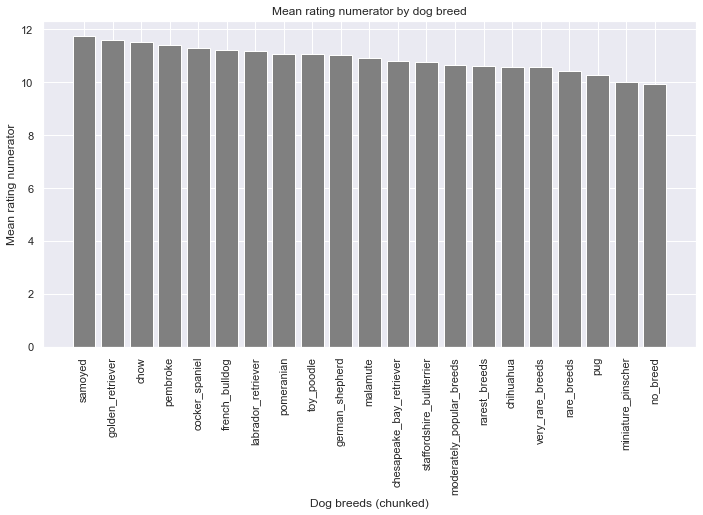

However, no single dog breed was statistically significantly higher rated than the rest (or dogs without predicted dog breed).

#### ... typical problems for dog breed classification:

- more than 1 dog on a picture
- wigs

[figure not shown]